# Abstract

# Introduction

# Methods and results

## Data aquisition

I downloaded the raw data and metadata files from MG-RAST[@MG-RAST] using the UNIX command line tool *wget*. They can be found under project ID numbers 98 (whole genome shotgun sequences) and 401 (16S rRNA V4 sequences).

## Preprocessing

### Metadata mapping files

To categorize and compare genome data, a link between sequenced sample files and their respective metadata is required. The MG-RAST database [@MG-RAST] provides a mapping file between sample data files and unique IDs with incomplete metadata, while Yatsunenko et al. [@Yats12] provide a complete metadata file without mapping to the sample data files. I applied the “calc” module of the *LibreOffice* suite to combine the contents of both files to a complete mapping file. For this I sorted both provided files' contents by their sample ID strings and copy-pasted missing rows from the MG-RAST mapping file into the metadata table. Two entries from the mapping file were not found in the metadata table, and Yatsunenko et al. also stated that two samples could not be used in the analysis, so I removed them from the metadata-mapping file. The result was saved as a tab-separated .csv file. On my system with German environment settings I had to convert decimal values from comma-separated values to international dot-separated format using the command line tool *sed*:

```
sed 's/,/\./g' 16s_mapping.csv > 16s_mapping_decimaldot.csv
```

The unique sequencer IDs differed from the sample IDs only by a numerical appendix, so I used a Python script to check if all samples were matched correctly:

TODO: move out to .py file

```python
def checkSampleIDmapping(fileName):
    print "checking", fileName, "-->",
    csv = open(fileName, "r")
    count = 0
    errors = 0
    csv.readline() # skip header

    for line in csv:
        line_split = line.split('\t')
        try:
            longID = line_split[0]
            shortID = line_split[1]
            if not longID.startswith(shortID):
                print "error in line", count, shortID, longID
                errors += 1
        except:
            pass
        count += 1

    print "read", count, "samples,", errors, "errors"

for fileName in ["16s_mapping_decimaldot.csv", "wgs_mapping_decimaldot.csv"]:
    checkSampleIDmapping(fileName)
```

Calling the script produced the following output:

```
checking 16s_mapping_decimaldot.csv --> read 528 samples, 0 errors
checking wgs_mapping_decimaldot.csv --> read 110 samples, 0 errors
```

### \(\alpha\)- and \(\beta\) diversity

Using the supported data and the manually created metadata mapping table, I followed the QIIME workflow to create tables of OTU abundances and analyse them for \(\alpha\)- and \(\beta\) diversity.

The first step required is to categorize the sequenced microorganisms into groups by phylogenetic distance. This step is called “picking”. To do this, I used the QIIME tool *pick_closed_reference.py*, which compares the samples to an existing similarity tree. As picking reference I used the GreenGenes database from 2011-02-04 and a similarity threshold of 97%, as did Yatsunenko et al. [@Yats12]. The picking was done on each sample individually, ten samples in parallel at any time, by using the custom Python script *picking.py*.

The QIIME tools for \(\alpha\)-rarefaction and \(\beta\)-diversity-analysis require a single biom table as input file, so I combined the picking results. A try to combine all 528 sample tables exceeded the computational power available, so I used the custom Python script *combine.py* which creates a shell script that calls the QIIME tool *merge_otu_tables.py* to iteratively add sample tables to a common table. A copy of this table was converted to a tab-separated file (\texttt{combined.csv}) for easy use with *R*.

From those rarefied OTU tables I calculated the \(\alpha\)- and \(\beta\)-diversity. I calculated \(\alpha\)-diversity using the tool *alpha_diversity.py* with the number of observed species as a disance measure and merged the results into a single table (\texttt{observed_species.csv}) with the tool *collate_alpha.py*. To measure \(\beta\)-diversity I used UniFrac distance, the percentage of shared branches on the phylogenetic tree, compared against the GreenGenes reference tree. With the tool *beta_diversity.py* I calculated \(\beta\)-diversity distance matrices for all ten rarefied tables, each with weighted and unweighted UniFrac distances as a measure. The resulting files are called \texttt{(unweighted_)unifrac_rarefaction_290000_N.txt}.

### Load data from preprocessed files

I loaded the data files created by the previous steps 3.2.1 and 3.2.2 and created convenience access methods.

```r
theCountries <- c("Malawi", "USA", "Venezuela")
theColors <- c("red", "blue", "green")
names(theColors) <- theCountries
alphaTable <- read.delim("local_copy/observed_species.csv")
betaTable <- read.delim("local_copy/unweighted_unifrac_rarefaction_290000_4.txt")
rownames(betaTable) <- betaTable[,1]; betaTable <- betaTable[,-1]
theMetadata <- read.delim("16s_mapping_decimaldot.csv")
rownames(theMetadata) <- theMetadata$X.SampleID
colnames(theMetadata)
```

```
##  [1] "X.SampleID"      "IDstring"        "Country"
##  [4] "Region"          "FamilyID"        "FamilyMember"
##  [7] "Age"             "Zygosity"        "Gender"
## [10] "BMI"             "BreastFed"       "SequenceCount"
## [13] "BarcodeSequence" "LinkerSequence"  "RunPrefix"
## [16] "FlowcellLane"
```

```r
 # get sample ids with label of specific value
getGroupIDs <- function(label, value) {
  theMetadata[theMetadata[,label] %in% value,]$X.SampleID
}
 # get sample ids with label in numeric range
getRangeIDs <- function(label, lower, upper) {
  values <- theMetadata[,label]
  theMetadata[values >= lower & values <= upper,]$X.SampleID
}
 # get beta variance data for samples with given ids
getBetaGroup <- function(label=NULL, value=NULL, range=FALSE, ids=NULL) {
  if (length(ids) == 0) {
    if (any(is.na(c(label,value)))) { # no input at all
      print("either label and value or ids required")
      return(c())
    }
    if (!range) ids <- getGroupIDs(label, value)
    else ids <- getRangeIDs(label, value[1], value[2])
  }
  betaTable[which(rownames(betaTable) %in% ids), which(colnames(betaTable) %in% ids)]
}
```

In this document, only one of 20 possible beta diversity matrices is loaded. The others were also processed, and the produced clusterings were very similar to the one shown here (see 3.2.5).

### UniFrac distance variation with age

Yatsunenko et al. observed the change of microbiome composition from infant-specific to adult configuration by comparing the composition of each child's microbiome against the microbiome composition of all adults from the same country [@Yats12]. As it is not completely clear how the distance to all adults was calculated I chose to use the mean of distances of the child to each adult.

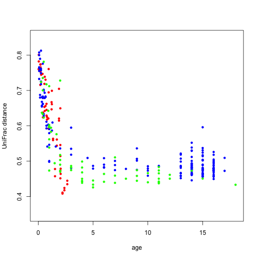

```r
plot(NULL, NULL, xlim=c(0, 18), ylim=c(0.35, 0.85), xlab="age", ylab="UniFrac distance")
country <- list(
    "USA" = getGroupIDs("Country", "USA"),
    "Malawi" = getGroupIDs("Country", "Malawi"),
    "Venezuela" = getGroupIDs("Country", "Venezuela")
    )
adults <- list(
    "USA" = intersect(country[["USA"]], getRangeIDs("Age", 19, 99)),
    "Malawi" = intersect(country[["Malawi"]], getRangeIDs("Age", 19, 99)),
    "Venezuela" = intersect(country[["Venezuela"]], getRangeIDs("Age", 19, 99))
    )
children <- list(
    "USA" = intersect(country[["USA"]], getRangeIDs("Age", 0, 18)),
    "Malawi" = intersect(country[["Malawi"]], getRangeIDs("Age", 0, 18)),
    "Venezuela" = intersect(country[["Venezuela"]], getRangeIDs("Age", 0, 18))
    )
for (country in theCountries) {
    for (child in children[[country]]) {
        betadiv <- getBetaGroup(ids=c(child, adults[[country]]))
        x <- theMetadata[theMetadata$X.SampleID==child,]$Age
        y <- sum(betadiv[child,]) / (nrow(betadiv) - 1)
        points(x, y, col=theColors[[country]], pch=20)
    }
}
legend(x=14, y=1.0, legend=theCountries, text.col=theColors)
```

The UniFrac distances start with high values at early ages, show a strong decline until approximately three years of age and stay steadily low until adulthood (see fig. 1).

### PCoA analysis of betadiversity

Partitioning Around Medoids (PAM) is a method of clustering data points into a given number k of groups. I initially assigns a data point as center for each of the groups and then minimizes a global distance function by iteratively swapping points and centers and assigning all data points to the nearest new center. Yatsunenko et al. used the \(\beta\)-distance matrix as a one-dimensional dissimilarity measure for the PAM algorithm and chose k=3 clusters to refind the samples' countries of origin in the microbiome composition [@Yats12]. I used the *pam* function from the *R* package *cluster* to repeat the process.

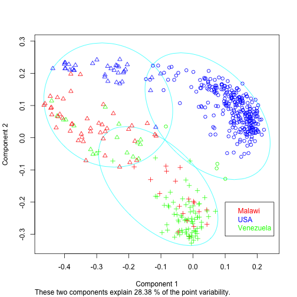

```r
clu <- pam(betaTable, diss=TRUE, k=3, keep.diss=TRUE)
clusplot(clu, col.p=c("red","blue","green")[theMetadata[names(clu$clustering),]$Country], main="")
legend(x=0.1, y=-0.2, legend=theCountries, text.col=theColors)
```

```r
 # note: color order is different, because the pamobject$clustering vector has a different order
contTable <- table(clu$clustering, theMetadata[names(clu$clustering),]$Country)
contTable <- cbind(contTable[,2], contTable[,1], contTable[,3]) # correct order
pam.result <- sum(diag(contTable) / sum(contTable))
print(pam.result)
```

```
## [1] 0.8407
```

Figure 2: Colors follow the real countries of origin, while symbols denote the country-clusters predicted by PAM. The plot shows a separated, banana-shaped distribution of US Americans and intermingled groups of Malawians and Venezuelans with concentrations for each subgroups. Using different rarefaction tables showed the same results of circa 84 per cent correct assignment.

### SVM classificator analysis of \(\beta\)-diversity

The PCoA plot suggested that discrimination of samples by microbiome diversity is possible. To improve the assignment I used the implementation of support vector machines (SVM) in the *R* package *e1071* [@e1071]. Support vector machines classify multi-dimensional datasets by finding a hyperplane that separates the classes among (a subset of) their features. It solves the problem of seemingly inseperable datasets by applying a “kernel function” that adds additional dimensions to the data's used features.

I trained a SVM to discriminate the dataset by different subsets of the OTUs that showed the greatest variance and compared the predicted samples with their countries of origin, using 20-fold cross validation.

```r
require(e1071)
species <- read.delim("local_copy/combined.csv", sep="\t", header=TRUE)
rownames(species) <- species[,1]
species <- species[,-1] # species level OTU table
species <- t(species)   # now rows = samples, cols = OTU counts
reps <- 20              # number of repetitions for cross validation
L <- nrow(species)
N <- L / reps           # number of samples per validation run
featureSizes <- c(1:5, seq(10, 500, len=10), ncol(species)) #
strength <- matrix(0, nrow=reps, ncol=length(featureSizes))
for (j in 1:length(featureSizes)) {
    allOfThem <- 1:L    # available samples
    for (i in 1:reps) {
        testSet <- sample(allOfThem, N)
        allOfThem <- allOfThem[-testSet]
        training <- c(1:L)[-testSet]
        variances <- apply(species[training,], 2, var)
        topVariables <- order(variances, decreasing=TRUE)
        topVariables <- topVariables[1:featureSizes[j]]
        trnNames <- rownames(species)[training]
        tstNames <- rownames(species)[testSet]
        model <- svm(x=species[training,topVariables], y=theMetadata[trnNames,]$Country);
        prediction <- predict(model, species[testSet,topVariables])
        contingency <- table(prediction, theMetadata[tstNames,]$Country)
        strength[i,j] <- sum(diag(contingency)) / sum(contingency)
    }
}
```

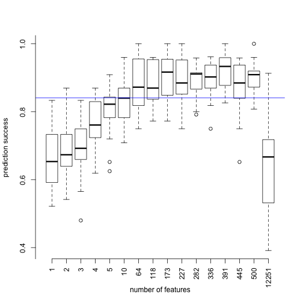

```r
boxplot(strength, xlab="number of features", ylab="prediction success", axes=FALSE)
abline(h=pam.result, col="blue")
axis(side=1, at=1:length(featureSizes), labels=as.integer(featureSizes), las=2)
axis(side=2, at=seq(from=0, to=1.2, by=0.2))
```

TODO: Draw evenly from all populations according to their size. Improve feature sizes, include 90, as stated in the paper. Maybe use p-values instead of variances (will be even slower).

### Bacterial diversity with age

Yatsunenko et al. found that the number of OTUs inside the fecal samples increased with age [@Yats12]. To verify this I calculated the means of OTU counts found in the ten rarefaction repetitions for each sample and plotted them against each samples' age.

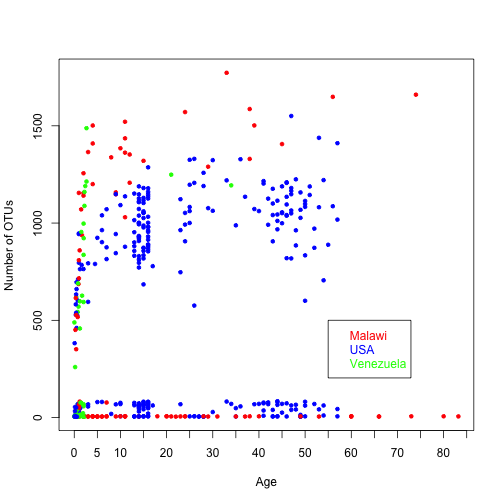

```r
rarefaction <- 188517
alpha <-alphaTable[alphaTable$sequences.per.sample==rarefaction,][,4:ncol(alphaTable)]
counts <- colMeans(data.matrix(alpha))
names(counts) <- colnames(alpha)
x <- theMetadata[names(counts),]$Age
cols <- c("green", "blue", "red")[theMetadata[names(counts),]$Country]
plot(x, counts, col=cols, pch=20, ylab="Number of OTUs", xlab="Age", lab=c(20, 6, 7))
legend(x=55, y=500, legend=theCountries, text.col=theColors)
```

TODO: Recompile on linux box, where the data doesn't “drop to the floor”. Find out, why these conversion errors appear on the Mac only.

The plot shows an increasing number of OTUs with increasing age (fig. 4).

### Processing of whole genome shotgun sequence data

- Paper: “preprocessing was done using custom Perl scripts and publicly available software tools”
- Filtering for degenerate sequences, duplicates: possible with custom script, but huge amounts of cpu time needed
- Further preprocessing unknown

Decisions

- created a *filter_wgs_reads.py* and then *faster_filter.py* for proof of concept, but didn't run them on the whole dataset
- downloaded data processed by automatized qiime workflow from MG-RAST (.stats files)
- try to recreate findings with this (different?) data
- found that even improved mapping files could not identify samples -> decided to ignore that part

\clearpage

# Discussion

Pro:

- 16S data analysis can be reproduced very well, plots virtually identical
- conclusions very plausible
- vast supplementary data available, so recreation of sample mapping possible

Con:

# Software used

TODO: Integrate properly into methods

The metadata mapping files were created using *LibreOffice* software suite version 4.2.4.2.  
The QIIME workflow was followed using the *QIIME* suite of software tools, version 1.8.0 as described by Caporaso et al. [@QIIME].  
Data analysis and visualization was done using the *R* statistical sofware version 3.1.0 [@R], the package *cluster* by Maechler et al. [@cluster] for partitioning around medoids and the package *e1071* by Meyer et al. [@e1071] for support vector machine classifiers.  
The custom Python scripts mentioned in the scope of this document can be found on [my github page](https://github.com/hermann-p/yatsunenko-2012-microbiome).